# Ensemble Methods

←Back to the bookChapter 108 · Ensemble Methods

Chapter 108 · Ensemble Methods

Ensemble Methods

Combining many weak learners into a strong one on an employee-attrition table: bagging and the random forest for variance, boosting (AdaBoost, gradient boosting, and the XGBoost / LightGBM / CatBoost family) for bias, and stacking, all library-first, visual, and cross-validated.

Statistics, Data Science and AI: A Visual Handbook · John Fisher · 2026

# Ensemble Methods: many weak learners, one strong model

A single decision tree is easy to read but easy to fool: too shallow and it underfits, too deep and it memorizes. **Ensembles** fix this by combining many trees. This notebook builds **bagging** and a **random forest** (average many trees to cut variance), **boosting** (grow trees in sequence, each fixing the last one's mistakes, to cut bias), and **stacking**, then races them on an employee-attrition table. Library-first with `scikit-learn`.

```python
import numpy as np, pandas as pd, matplotlib.pyplot as plt
import seaborn as sns   # seaborn = high-level statistical plots (heatmaps, pairplots, count/bar plots)
from matplotlib.colors import ListedColormap
EM="#4338ca"; DEEP="#3730a3"; LIGHT="#c7d2fe"; INK="#1a2138"; GRID="#e6e9f2"; RED="#ef4444"; AMBER="#d97706"; GREEN="#059669"; BLUE="#2563eb"; PUR="#9333ea"; GREY="#94a3b8"; SLATE="#475569"; ORG="#4338ca"; CYAN="#0891b2"
plt.rcParams.update({"figure.facecolor":"white","axes.facecolor":"white","figure.dpi":110,"font.size":11,
   "axes.edgecolor":GRID,"axes.grid":True,"grid.color":GRID,"axes.axisbelow":True,"axes.spines.top":False,
   "axes.spines.right":False,"axes.titlesize":12,"axes.titleweight":"bold","legend.frameon":False})
sns.set_style("whitegrid")
BASE="https://raw.githubusercontent.com/johnfisher-ai/Statistics-Data-Science-AI-Visual-Book/main/data/"
```

```python
import warnings; warnings.filterwarnings('ignore')
from sklearn.model_selection import train_test_split, cross_val_score
from sklearn.tree import DecisionTreeClassifier
from sklearn.ensemble import (BaggingClassifier, RandomForestClassifier, GradientBoostingClassifier,
    AdaBoostClassifier, StackingClassifier)
from sklearn.linear_model import LogisticRegression
from sklearn.preprocessing import StandardScaler
from sklearn.pipeline import make_pipeline
from sklearn.metrics import accuracy_score
pd.set_option('display.max_columns', 30)
```

DEMO 1 · THE BASE LEARNER OVERFITS

One tree is not enough

A single unpruned tree memorizes the training data.

```python
try: df = pd.read_excel('../../data/ensemble-methods--attrition.xlsx', sheet_name='Data')
except FileNotFoundError: df = pd.read_excel(BASE + 'ensemble-methods--attrition.xlsx', sheet_name='Data')
feat = ['satisfaction','last_evaluation','num_projects','avg_monthly_hours','tenure_years',
        'work_accident','promotion_5yr','salary_level','noise_a','noise_b']
X, y = df[feat], df['left']
X_train, X_test, y_train, y_test = train_test_split(X, y, test_size=0.25, random_state=0, stratify=y)
tree = DecisionTreeClassifier(random_state=0).fit(X_train, y_train)
print(f'single full tree: train {tree.score(X_train,y_train):.3f}  vs  5-fold CV {cross_val_score(DecisionTreeClassifier(random_state=0), X, y, cv=5).mean():.3f}')
print(f'attrition rate {y.mean():.0%}  (majority-class baseline {1-y.mean():.3f})')
```

```
single full tree: train 1.000  vs  5-fold CV 0.704
attrition rate 40%  (majority-class baseline 0.602)
```

**The problem.** A single unrestricted decision tree scores a perfect **1.00 on its training data** but only about **0.70 in cross-validation**, worse than a plain logistic regression. It has memorized noise (including the two junk `noise` columns) instead of learning the pattern. The attrition risk here is genuinely nonlinear, a three-way interaction of high performers who are overworked and never promoted, so one tree cannot win. Ensembles are the fix.

DEMO 2 · BAGGING & THE RANDOM FOREST

Average many trees to cut variance

Each tree sees a bootstrap sample; the forest votes.

```
bagging      5-fold CV = 0.777
```

```
random forest 5-fold CV = 0.782
random forest OOB score = 0.793   (free validation from the un-sampled rows)
```

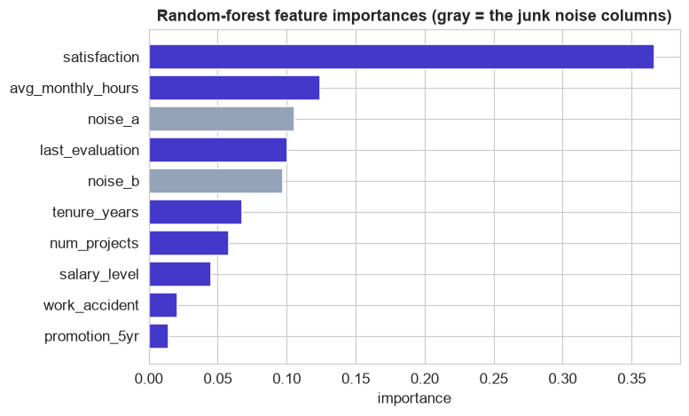

```python
bag = BaggingClassifier(n_estimators=300, random_state=0)
rf  = RandomForestClassifier(n_estimators=300, oob_score=True, random_state=0).fit(X_train, y_train)
print(f'bagging      5-fold CV = {cross_val_score(bag, X, y, cv=5).mean():.3f}')
print(f'random forest 5-fold CV = {cross_val_score(RandomForestClassifier(n_estimators=300, random_state=0), X, y, cv=5).mean():.3f}')
print(f'random forest OOB score = {rf.oob_score_:.3f}   (free validation from the un-sampled rows)')
imp = pd.Series(rf.feature_importances_, index=feat).sort_values()
fig, ax = plt.subplots(figsize=(7.2,4.4))
ax.barh(imp.index, imp.values, color=[GREY if 'noise' in f else EM for f in imp.index])
ax.set(title='Random-forest feature importances (gray = the junk noise columns)', xlabel='importance'); plt.tight_layout(); plt.show()
```

DEMO 3 · SMOOTHER DECISION BOUNDARY

The forest generalizes where the tree overfits

Trained on two features so we can see it.

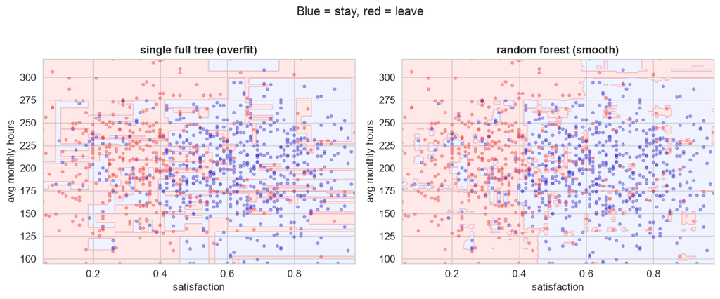

```python
X2 = df[['satisfaction','avg_monthly_hours']].values; yv = df['left'].values
xx, yy = np.meshgrid(np.linspace(X2[:,0].min(), X2[:,0].max(), 250), np.linspace(X2[:,1].min(), X2[:,1].max(), 250))
fig, axes = plt.subplots(1, 2, figsize=(11,4.4))
for ax,(name,m) in zip(axes, [('single full tree (overfit)', DecisionTreeClassifier(random_state=0)), ('random forest (smooth)', RandomForestClassifier(n_estimators=300, random_state=0))]):
    m.fit(X2, yv)
    Z = m.predict(np.c_[xx.ravel(), yy.ravel()]).reshape(xx.shape)
    ax.contourf(xx, yy, Z, alpha=0.25, cmap=ListedColormap([LIGHT, '#fca5a5']))
    ax.scatter(X2[:,0], X2[:,1], c=yv, cmap=ListedColormap([EM, RED]), s=8, alpha=0.4)
    ax.set(title=name, xlabel='satisfaction', ylabel='avg monthly hours')
plt.suptitle('Blue = stay, red = leave', y=1.02); plt.tight_layout(); plt.show()
```

DEMO 4 · BOOSTING

Grow trees in sequence, each fixing the last

Boosting reduces bias; watch accuracy climb as trees are added.

```
gradient boosting 5-fold CV = 0.789
```

```
AdaBoost          5-fold CV = 0.791
```

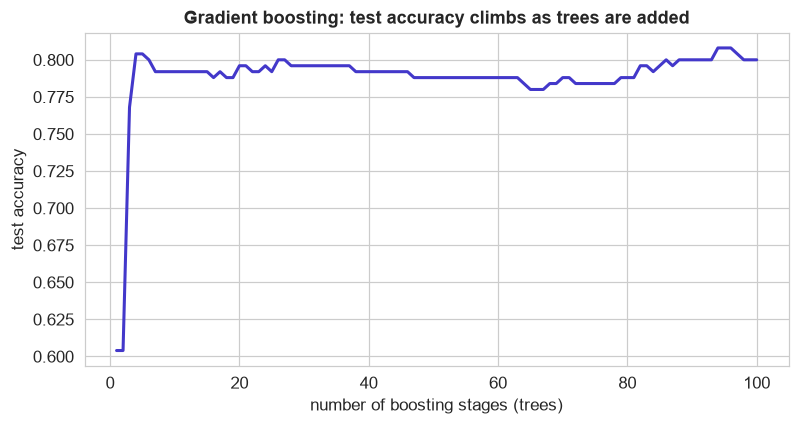

```python
gb = GradientBoostingClassifier(random_state=0).fit(X_train, y_train)
ada = AdaBoostClassifier(n_estimators=200, random_state=0)
print(f'gradient boosting 5-fold CV = {cross_val_score(GradientBoostingClassifier(random_state=0), X, y, cv=5).mean():.3f}')
print(f'AdaBoost          5-fold CV = {cross_val_score(ada, X, y, cv=5).mean():.3f}')
acc = [accuracy_score(y_test, p) for p in gb.staged_predict(X_test)]
fig, ax = plt.subplots(figsize=(7.4,4))
ax.plot(range(1, len(acc)+1), acc, color=EM, lw=2)
ax.set(title='Gradient boosting: test accuracy climbs as trees are added', xlabel='number of boosting stages (trees)', ylabel='test accuracy')
plt.tight_layout(); plt.show()
```

DEMO 5 · STACKING

Let a meta-model combine the others

Blend diverse models with a final learner.

```python
stack = StackingClassifier(
    estimators=[('rf', RandomForestClassifier(n_estimators=200, random_state=0)),
                ('gb', GradientBoostingClassifier(random_state=0)),
                ('lr', make_pipeline(StandardScaler(), LogisticRegression(max_iter=1000)))],
    final_estimator=LogisticRegression(), cv=5)
print(f'stacking 5-fold CV = {cross_val_score(stack, X, y, cv=5).mean():.3f}')
```

```
stacking 5-fold CV = 0.789
```

**What stacking does.** Instead of a simple vote, **stacking** trains a small **meta-model** to learn *how much to trust each base model*, using their cross-validated predictions as inputs. It shines when the base learners are **diverse** (here a forest, a booster, and a linear model make different kinds of error), so the meta-model can combine their strengths. It is the technique behind many winning competition entries, at the cost of more compute and less interpretability.

DEMO 6 · THE FULL RACE

From one tree to the ensembles

Cross-validated accuracy, worst to best.

```
single tree (full)     0.704
logistic regression    0.770
bagging                0.777
random forest          0.782
gradient boosting      0.789
stacking               0.789
AdaBoost               0.791
```

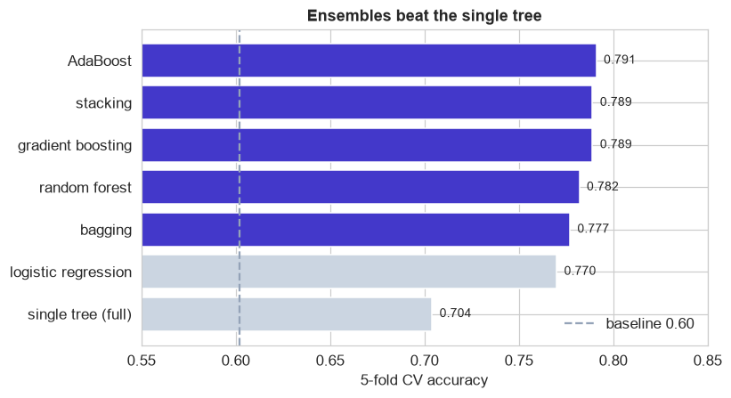

```python
models = {'single tree (full)': DecisionTreeClassifier(random_state=0),
          'logistic regression': make_pipeline(StandardScaler(), LogisticRegression(max_iter=1000)),
          'bagging': BaggingClassifier(n_estimators=300, random_state=0),
          'random forest': RandomForestClassifier(n_estimators=300, random_state=0),
          'AdaBoost': AdaBoostClassifier(n_estimators=200, random_state=0),
          'gradient boosting': GradientBoostingClassifier(random_state=0),
          'stacking': stack}
cv = pd.Series({k: cross_val_score(m, X, y, cv=5).mean() for k,m in models.items()}).sort_values()
print(cv.round(3).to_string())
fig, ax = plt.subplots(figsize=(7.6,4.2))
colors = ['#cbd5e1' if 'tree' in k or 'logistic' in k else EM for k in cv.index]
ax.barh(cv.index, cv.values, color=colors)
ax.axvline(1-y.mean(), color=GREY, ls='--', label=f'baseline {1-y.mean():.2f}')
for i,v in enumerate(cv.values): ax.text(v+0.004, i, f'{v:.3f}', va='center', fontsize=9)
ax.set(title='Ensembles beat the single tree', xlabel='5-fold CV accuracy', xlim=(0.55, 0.85)); ax.legend(loc='lower right')
plt.tight_layout(); plt.show()
```

**The verdict.** The lone overfit tree sits at the bottom; every **ensemble** lands at the top, with boosting and stacking edging out the forest. The lesson is not that one ensemble always wins, but that **combining many models beats relying on one**, either by averaging away variance (bagging / random forest) or by sequentially reducing bias (boosting). For tabular data, a tuned gradient-boosting model is very often the strongest thing you can reach for.

## Ensembles, in one view

- **Bagging** trains many models on bootstrap resamples and averages them, cutting **variance**; the **random forest** adds random feature subsets so the trees are more independent.
- **Boosting** grows models **sequentially**, each correcting the last, cutting **bias**; AdaBoost and gradient boosting (XGBoost / LightGBM / CatBoost) are the workhorses.
- **Stacking** trains a meta-model to blend diverse base models.
- Ensembles trade interpretability and compute for accuracy; on tabular data they are usually the top performers, which is why boosted trees dominate competitions.

Statistics, Data Science and AI: A Visual Handbook · © 2026 John Fisher

←Back to the bookChapter 108 · Ensemble Methods